# GMAP Potri gene alignments to the Potra genome stats

Nicolas Delhomme

2015-08-25

# 1 Setup

Set the working dir

```r
setwd("/mnt/picea/projects/aspseq/asp201/rna/gmap/Potra01/")
```

Load libraries

```r
suppressPackageStartupMessages(library(Biostrings))
suppressPackageStartupMessages(library(genomeIntervals))
suppressPackageStartupMessages(library(GenomicRanges))
suppressPackageStartupMessages(library(LSD))
suppressPackageStartupMessages(library(pander))
suppressPackageStartupMessages(library(RColorBrewer))
```

Source helpers

```r
source("~/Git/UPSCb/src/R/plot.multidensity.R")
```

Graphic params

```r
mar <- par("mar")
pal <- brewer.pal(8,"Dark2")
```

# 2 Analysis

Reading in the synthetic transcript set

```r
fa <- readDNAStringSet("/mnt/picea/storage/reference/Populus-trichocarpa/v3.0/fasta/Potri03-synthetic-transcripts.fa")
```

Reading in the gmap gff3 files

```r
uniq <- readGff3("Potra01-Potri03-synthetic-transcripts.gff3.uniq")
multi <- readGff3("Potra01-Potri03-synthetic-transcripts.gff3.mult")
transloc <- readGff3("Potra01-Potri03-synthetic-transcripts.gff3.transloc")
```

## 2.1 Unique

Get the mRNA

```r
sel <- uniq$type=="mRNA"
uniq.df <- as.data.frame(getGffAttribute(uniq[sel,],c("Name","coverage","identity")))
uniq.df$coverage <- as.numeric(as.character(uniq.df$coverage))
uniq.df$identity <- as.numeric(as.character(uniq.df$identity))
```

Plot the coverage and identity

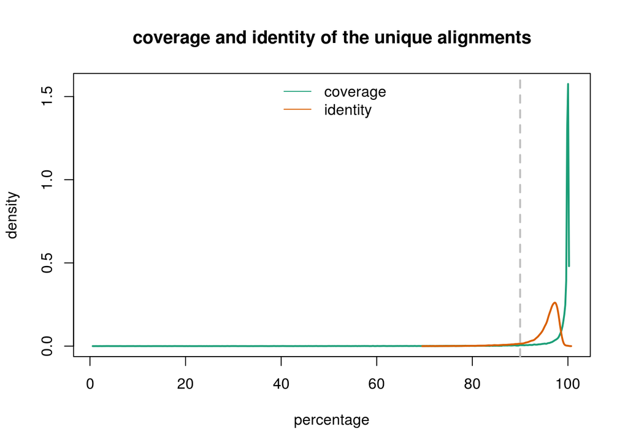

```r
plot.multidensity(list(coverage=uniq.df$coverage,identity=uniq.df$identity),
                  legend.x="top",xlab="percentage",lwd=2,
                  main="coverage and identity of the unique alignments")
abline(v=90,col="grey",lwd=2,lty=2)
```

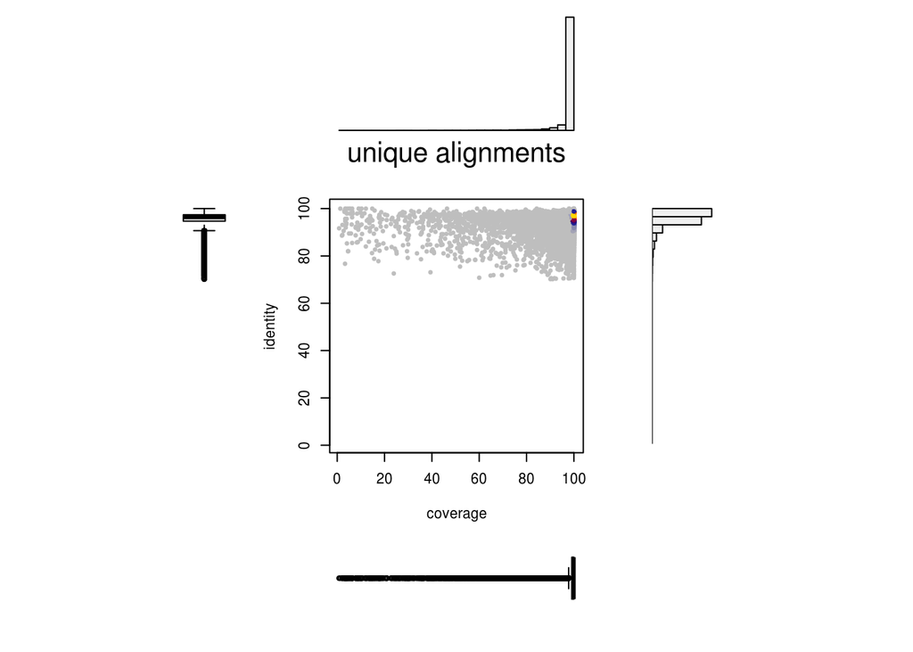

```r
comparisonplot(uniq.df$coverage,uniq.df$identity,xlab="coverage",
               ylab="identity",main="unique alignments")
```

## 2.2 Multi

Get the mRNA

```r
sel <- multi$type=="mRNA"
multi.df <- as.data.frame(getGffAttribute(multi[sel,],c("Name","coverage","identity")))
multi.df$coverage <- as.numeric(as.character(multi.df$coverage))
multi.df$identity <- as.numeric(as.character(multi.df$identity))
```

Plot the coverage and identity

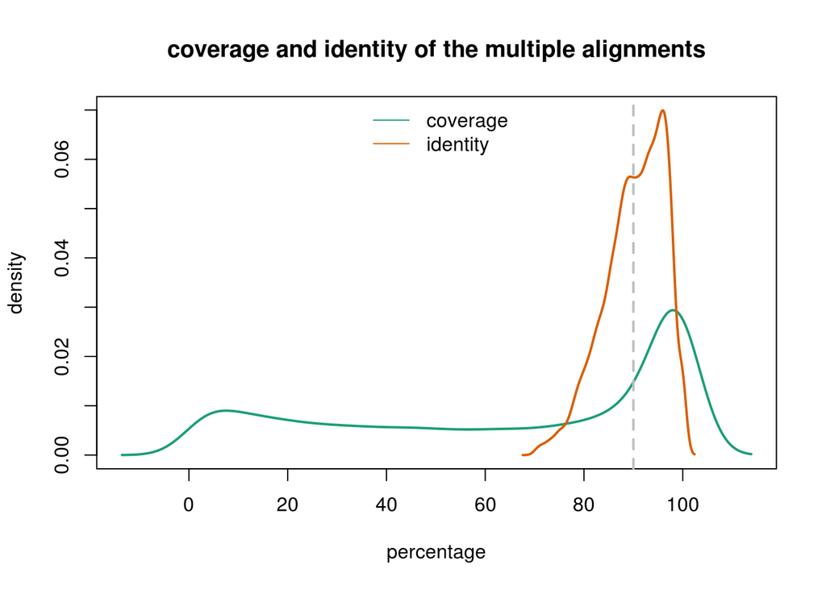

```r
plot.multidensity(list(coverage=multi.df$coverage,identity=multi.df$identity),
                  legend.x="top",xlab="percentage",lwd=2,
                  main="coverage and identity of the multiple alignments")
abline(v=90,col="grey",lwd=2,lty=2)
```

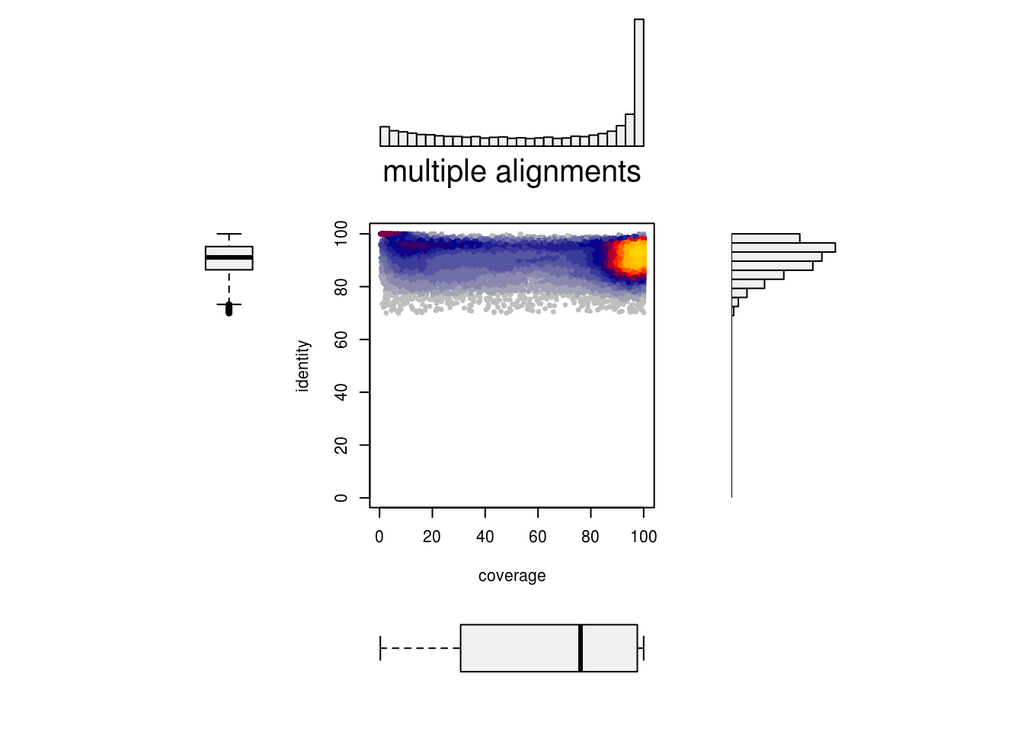

```r
comparisonplot(multi.df$coverage,multi.df$identity,xlab="coverage",
               ylab="identity",main="multiple alignments")
```

```r
table(sub(".*path","",getGffAttribute(multi[multi$type=="gene",],"ID")))
```

```
##
##    1    2    3    4    5
## 5306 5306 2160 1086  645
```

Get the gene coverage. Indeed for the multiple, the situation is more complex as some multiple are also split across scaffolds and some multiple are simply partial; e.g. a very conserved domain. Hence, we calculate the cumulative binary coverage of the multiple (0 if a bp is missed, one if it is covered at least once) and use that for the filtering later on. Given the GMAP results, we can not anyway deconvolve the right mRNA structures when the alignment is split across scaffolds.

```r
tgt.df <- do.call(rbind,strsplit(getGffAttribute(multi[multi$type=="exon",],"Target")," "))
tgt.grng <- GRanges(seqnames=tgt.df[,1],
                    ranges=IRanges(start=as.numeric(tgt.df[,2]),
                                   end=as.numeric(tgt.df[,3])),
                    strand=tgt.df[,4])

bp.cov <- unlist(lapply(coverage(reduce(tgt.grng,ignore.strand=TRUE)),sum))
multi.cum.cov <- (bp.cov/width(fa)[match(names(bp.cov),names(fa))]) * 100
multi.mean.id <- unlist(as.list(by(multi.df$identity,multi.df$Name,mean)))
stopifnot(all(names(multi.cum.cov) == names(multi.mean.id)))
```

Let’s just check how taking the mean affect the multi mapping identity. From the multi mapping hits, we can see a bimodal curve with a long tail. Taking the mean show a more narrow distribution with an higher mode averaging the multi mapping curve modes. This implies that the multi mapping often map best to one loci and less to another (WGD remnants?); and that summarising the multiple in that way is not affecting the values at a 70% cutoff, but is slightly more lenient at the 80 and 90% cutoffs.

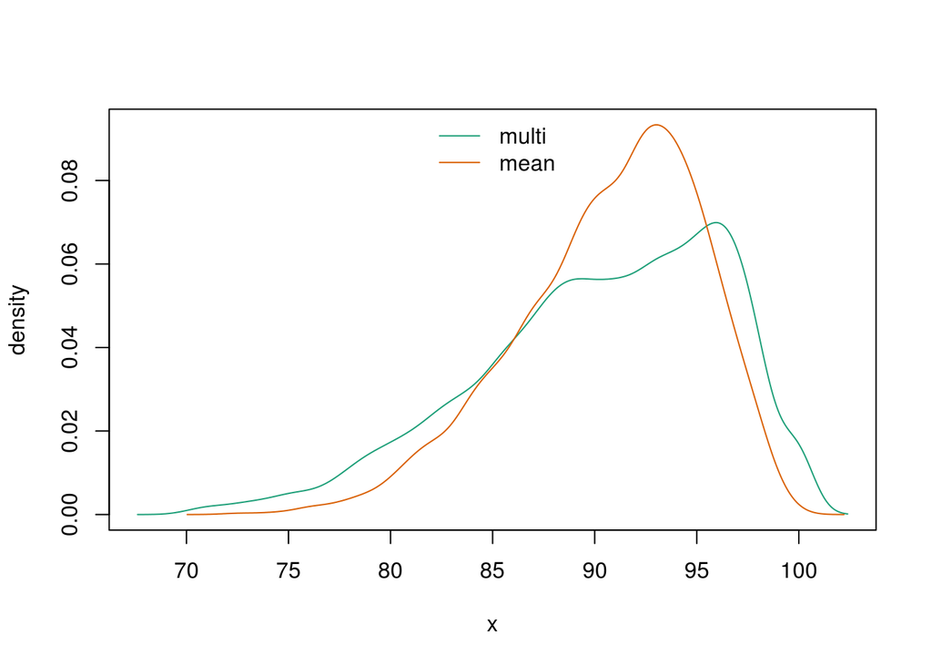

```r
plot.multidensity(list(multi=multi.df$identity,mean=multi.mean.id))
```

## 2.3 Translocation

Not real translocatoin here, but assembly fragmentation

Get the mRNA

```r
sel <- transloc$type=="mRNA"
transloc.df <- as.data.frame(getGffAttribute(transloc[sel,],c("Name","coverage","identity")))
transloc.df$coverage <- as.numeric(as.character(transloc.df$coverage))
transloc.df$identity <- as.numeric(as.character(transloc.df$identity))
```

Plot the coverage and identity

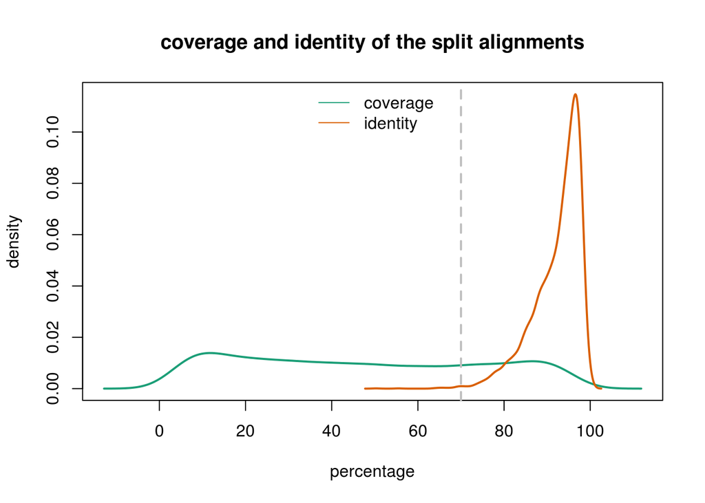

```r
plot.multidensity(list(coverage=transloc.df$coverage,identity=transloc.df$identity),
                  legend.x="top",xlab="percentage",lwd=2,
                  main="coverage and identity of the split alignments")
abline(v=70,col="grey",lwd=2,lty=2)
```

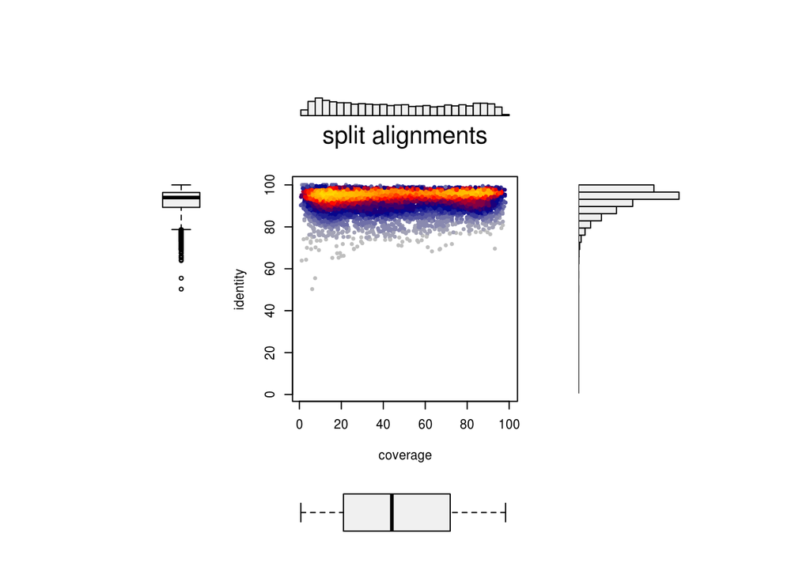

```r
comparisonplot(transloc.df$coverage,transloc.df$identity,xlab="coverage",
               ylab="identity",main="split alignments")
```

Just a check to verify the assumption that transloc only have one spli “path”

```r
stopifnot(diff(table(sub(".*path","",getGffAttribute(transloc[transloc$type=="gene",],"ID"))))==0)
```

Calculate the transloc cumulative coverage

```r
transloc.cum.df <- data.frame(Name=unique(transloc.df$Name),
                          coverage=unlist(as.list(by(transloc.df$coverage,transloc.df$Name,sum))),
                          identity=unlist(as.list(by(transloc.df$identity,transloc.df$Name,mean))))
```

# 3 Cumulated statistics

We check 3 thresholds

```r
thresholds <- c(70,80,90)
res <- sapply(thresholds,function(threshold){
  c(
    unique=sum(uniq.df$coverage >= threshold & uniq.df$identity >= threshold),
    multiple=sum(multi.cum.cov >= threshold & multi.mean.id >= threshold),
    split=sum(transloc.cum.df$coverage >= threshold & transloc.cum.df$identity >= threshold))
})
colnames(res) <- thresholds
```

## 3.1 All thresholds

```r
pander(res)
```

|  | 70 | 80 | 90 |
| --- | --- | --- | --- |
| **unique** | 32002 | 31504 | 29147 |
| **multiple** | 4751 | 4356 | 2382 |
| **split** | 2645 | 2456 | 1654 |

## 3.2 90% length, 90% identity

```r
sprintf("There are %s %% (%s out of %s) Potri genes aligning at a cutoff of 90%%",
        round(sum(res[,"90"])*100/length(fa),digits=2),
        sum(res[,"90"]),
        length(fa))
```

```
## [1] "There are 80.28 % (33183 out of 41335) Potri genes aligning at a cutoff of 90%"
```

## 3.3 80% length, 80% identity

```r
sprintf("There are %s %% (%s out of %s) Potri genes aligning at a cutoff of 80%%",
        round(sum(res[,"80"])*100/length(fa),digits=2),
        sum(res[,"80"]),
        length(fa))
```

```
## [1] "There are 92.7 % (38316 out of 41335) Potri genes aligning at a cutoff of 80%"
```

```r
## 70% length, 70% identity
sprintf("There are %s %% (%s out of %s) Potri genes aligning at a cutoff of 70%%",
        round(sum(res[,"70"])*100/length(fa),digits=2),
        sum(res[,"70"]),
        length(fa))
```

```
## [1] "There are 95.31 % (39398 out of 41335) Potri genes aligning at a cutoff of 70%"
```

## 3.4 Quantify split genes

First we get the maximal mappable prefix per split gene (transloc and all multiple). For the multiple, it is harder to estimate what is a split gene ( far from impossible, using a coverage cutoff and looking at the number of scaffolds), but since the statistics we went to report is the number of gene which have 50% of their length within one scaffold, this info is not necessary.

```r
mmp <- list(transloc=unlist(as.list(by(transloc.df$coverage,transloc.df$Name,max))),
            multiple=unlist(as.list(by(multi.df$coverage,multi.df$Name,max))))
```

Clearly the proportion of transloc in the multiple is minimal compared to complete redundancy (due to tandem repeat or the WGD).

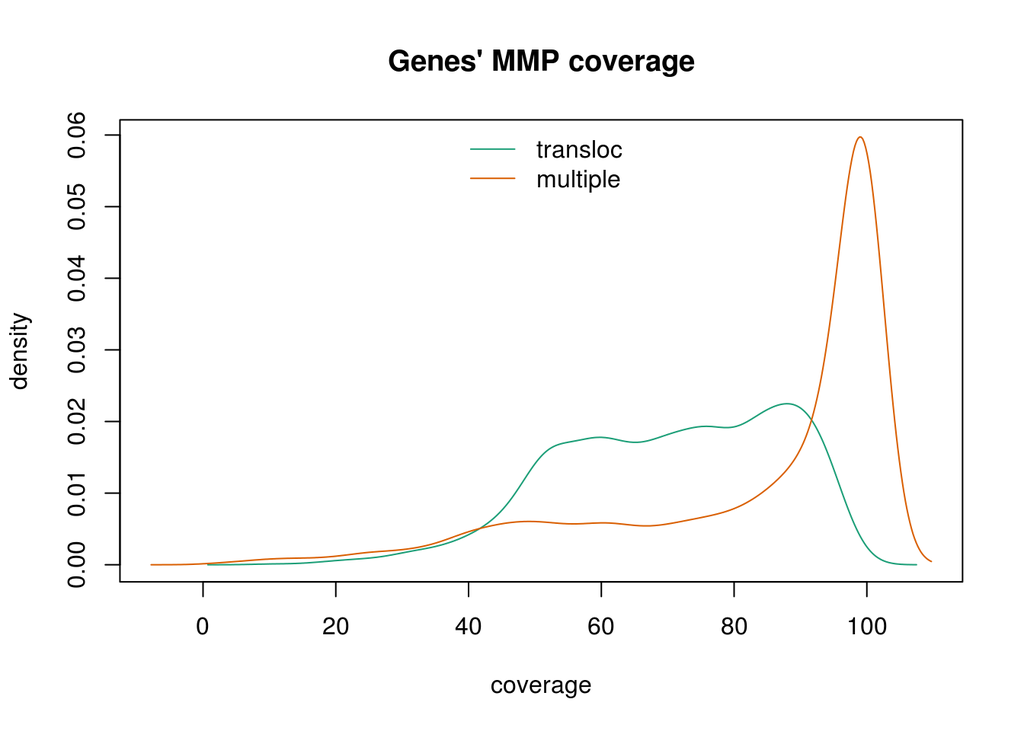

```r
plot.multidensity(mmp, xlab="coverage",main="Genes' MMP coverage")
```

Report for the three thresholds

```r
long <- sapply(thresholds,function(threshold){
  sum(c(sum(uniq.df$coverage >= threshold &
              uniq.df$identity >= threshold),
        sum(mmp$transloc[match(transloc.cum.df[transloc.cum.df$coverage >= threshold &
                                                 transloc.cum.df$identity >= threshold,"Name"],
                               names(mmp$transloc))]>50),
        sum(mmp$multiple[match(names(multi.mean.id)[multi.cum.cov >= threshold &
                                                      multi.mean.id >= threshold],
                               names(mmp$multiple))]>50)
  ))
})
names(long) <- thresholds
pander(long)
```

| 70 | 80 | 90 |
| --- | --- | --- |
| 39008 | 38106 | 33138 |

And as percentage of the number of aligned genes

```r
pander(round(100* long / colSums(res),digits=2))
```

| 70 | 80 | 90 |
| --- | --- | --- |
| 99.01 | 99.45 | 99.86 |

## 3.5 No alignments

```r
sprintf("There are %s Potri genes without any alignment evidence.",
        sum(!names(fa) %in% c(as.character(uniq.df$Name),
                              as.character(transloc.cum.df$Name),
                              names(multi.cum.cov))))
```

```
## [1] "There are 605 Potri genes without any alignment evidence."
```

# 4 Conclusion

In total 95.31% (39398 of 41335) of Potri genes were represented within the assembly (alignment >70% length and >70% identity) with 99% being present with >50% gene length within a single scaffold. 605 genes showed no evidence of alignment.